# P4_S7 Informe

UTEC - Universidad de Ingeniería y Tecnología

### **Estadística y Probabilidades**

#### **¿Cómo afecta la virtualidad a los estudiante de UTEC en el el ámbito académico?**

**I. Introducción**

La pandemia del Covid-19 ha afectado la gran mayoría de actividades comunes. Una de esas actividades ha sido la estudiantil que pasó de una modalidad presencial a una virtual de manera repentina tomando en cuenta las complejidades de este modelo de enseñanza. Muchas de las instituciones educativas, entre ellas las universidades, tomaron la decisión de la enseñanza virtual para que los estudiantes no perdieran el ciclo universitario. Aceptar esta modalidad ha sido la opción que la gran mayoría de estudiantes ha decidido; sin embargo, la virtualidad ha afectado a los estudiantes tanto de manera positiva como negativa.  
Por el motivo explicado en el párrafo anterior, nos han surgido las preguntas como: ¿Los estudiantes se sienten conformes con las clases virtuales? ¿Han aprendido mejor en las clases virtuales? ¿Subieron o bajaron sus notas? Por medio de este estudio queremos dar a conocer cuáles son los efectos de las clases virtuales en los estudiantes de UTEC en el ámbito académico.

**II. Importancia**

Este estudio nos ayudará a recolectar información sobre el desempeño académico de los estudiantes de UTEC y saber qué tanto ha mejorado con la llegada de las clases virtuales. Es muy importante conocer las dificultades que atravesaron los alumnos durante sus ciclos y con estos de datos se podrá llegar a responder la pregunta que hemos planteado como proyecto, y así poder ayudar a los estudiantes que tuvieron dificultades con la data que obtendremos.

**III. Justificación**

El estudio aportará conclusiones de preferencias de los estudiantes de UTEC. Así como, mostrar comparaciones en el desempeño académico de los estudiantes que tuvieron la oportunidad de llevar al menos un ciclo presencial y que pasaron a la virtualidad. De esta manera, podremos saber si ha beneficiado o no a los estudiantes por diversos factores, por ejemplo: comodidad, conexión a internet estable, problemas personales a causa de la pandemia, etc.

**IV. Factibilidad**

Este estudio cuenta con los recursos necesarios para llevar a cabo nuestros objetivos y metas, pues contamos con la participación de alumnos que pasaron de una educación presencial a virtual. Además de contar con el tiempo suficiente para recolectar una cantidad representativa de estudiantes y manejar nuestra data.

**V. Objetivos**

- *1. Objetivo General*: Comparar el rendimiento académico entre el ciclo presencial y virtual, mediante su promedios ponderados académicos. Al mismo tiempo, dar a conocer cómo ha afectado la modalidad virtual a los estudiantes que habían aprobado todos los cursos durante su último ciclo presencial y el último ciclo virtual, verificar si su promedio ponderado es mayor a los que desaprobaron cursos en ambas modalidades.
- *2. Pregunta General*: ¿Cómo afectó la virtualidad en el ámbito académico a los estudiantes de UTEC en sus promedios ponderados?

**VI. Marco Teórico**

- *1. Población Objetivo*: Estudiantes de UTEC que han llevado al menos un ciclo presencial.
- *2. Tipo de Muestreo*: Muestreo por conveniencia, debido a que solo consideramos a estudiantes de UTEC que han llevado al menos un ciclo presencial. Esperamos que más de 150 estudiantes llenen la encuesta para obtener una muestra representativa.
- *3. Unidades Muestrales*: Se cuenta actualmente con 164 estudiantes encuestados.
- *4. Interesados*: Los interesados de este estudio son los estudiantes y profesores de UTEC; ya que, al tener conocimiento de este tema y de las referencias de los alumnos se podría solucionar ciertos factores de la modalidad virtual para la mejora del rendimiento académico de los estudiantes.

**VII. Variables**:

- **Código**
- **Edad**
- **Carrera**
- **Ciclo**
- **NúmCursosMáxCP**: ¿Cuántos cursos como máximo has llevado en el ciclo presencial? (Opción de elegir el número de cursos del 1 al 11).
- **CursoDesaprobadoCP**: ¿Has desaprobado algún curso en tu ciclo presencial? (Si/No).
- **PromUltimoCP**: Promedio del último ciclo presencial (aproximado) (Opción de elegir una nota del 5 al 20)
- **CursoDesaprobadoCV**: ¿Has desaprobado algún curso en tu ciclo virtual? (Si/No).
- **NúmCursosMáxCV**: ¿Cuántos cursos como máximo has llevado en el ciclo virtual? (Opción de elegir del 1 al 13).
- **PromÚltimoCV**: Promedio del último ciclo presencial (aproximado) (Opción de elegir del 5 al 20).
- **SatisfechoCV**: En una escala del 1 al 5 qué tan conforme te sientes con las clases virtuales (siendo 1 la escala más baja y 5 la escala más alta) (Opción a elegir del 1 al 5).
- **AprendizajeMod**: ¿Con qué modalidad sientes que has aprendido más? (Presencial/Virtual).
- **NoBenficioCV**: ¿Cuál de estas opciones consideras tú que no te beneficia de las clases virtuales?
- **BeneficioCV**: ¿Cuál de estas opciones es el mejor beneficio de las clases virtuales?
- **ModComplicada**: ¿Cuál de las modalidades crees tú que es más la complicada?
- **CursosRetCP**: ¿En el ciclo presencial, de cuántos cursos te has retirado como máximo?
- **CursosRetCv**: ¿En el ciclo virtual, de cuantos cursos te has retirado?
- **ProbCV**: ¿Qué problemas se te han presentado en el ciclo virtual?
- **Conexion**: ¿Cuál de estas opciones es el segundo mejor beneficio de las clases virtuales?
- **SegOpcC**: ¿Cuál de estas opciones es el segundo mejor beneficio de las clases virtuales?

**VIII. Tabla - Tipos de Variables**

| Variables | Tipo |
| --- | --- |
| Código | Categórica → Ordinal |
| Edad | Numérica → Discreta |
| Carrera | Categórica → Nominal |
| Ciclo | Categórica → Ordinal |
| NúmCursosMáxCP | Numérica→ Discreta |
| CursoDesaprobadoCP | Numérica → Discreta |
| PromUltimoCP | Numérica→ Discreta |
| CursoDesaprobadoCV | Numérica→ Discreta |
| NúmCursosMáxCV | Numérico→ Discreta |
| PromÚltimoCV | Numérico→ Discreta |
| SatisfechoCV | Categórica→ Nominal |
| AprendizajeMod | Categórica→ Nominal |
| NoBenficioCV* | Categórica→ Nomina |
| BeneficioCV* | Categórica→ Nominal |
| ModComplicada* | Categórica→ Nominal |
| CursosRetCP* | Categórica→ Discreta |
| CursosRetCv* | Categórica→ Discreta |
| ProbCV* | Categórica→ Nominal |
| Conexion* | Categórica→ Ordinal |
| SegOpcC* | Categórica→ Nominal |

**IX. Procesamiento de Datos**

Instalaremos las librerías para garantizar una correcta ejecución del proyecto:

```r
lista.paquetes <- c("readr", "dplyr","modeest")
nuevos.paquetes <- lista.paquetes[!(lista.paquetes %in% installed.packages()[,"Package"])]
if(length(nuevos.paquetes)) install.packages(nuevos.paquetes)
```

Cargando librerías:

```r
library(readr)
library(dplyr)
library(modeest)
library(vctrs)
DF<-read_csv("VirtualidadEstudiantes2.csv");
colnames(DF)[3:24]<-c("Filtro","Codigo", "Sexo", "Edad", "Ciclo", "Carrera", "NumCursosMaxCP", "CursoDesaprobadoCP", "PromUltimoCP", "CursoDesaprobadoCV" , "NumCursosMaxCV", "PromUltimoCV", "SatisfechoCV", "AprendizajeMod", "NoBenficioCV",
"BeneficioCV", "ModComplicada", "CursosRetCP", "CursosRetCv", "ProbCV", "Conexion", "SegOpcCV")
```

```r
DF1 <- filter(DF, DF$Filtro == "Si")
```

```r
DfLast <- select(DF1,Codigo:SegOpcCV)
```

**X. Entendiendo nuestra muestra:**

**Tamaño de la muestra**

Seleccionamos una confianza del 95% porque estimamos que la población de UTEC es pequeña

```r
a <- 1-0.95
a2 <- a/2
complemento <- 1-a2

a
```

```
## [1] 0.05
```

```r
a2
```

```
## [1] 0.025
```

```r
complemento
```

```
## [1] 0.975
```

Hallamos $Z_{a/2}$:

```r
round((qnorm(0.025,0,1)), digits = 2)
```

```
## [1] -1.96
```

```r
round((qnorm(0.975,0,1)), digits =2)
```

```
## [1] 1.96
```

Estimamos una población de N ~ 2000 entonces el tamaño de la muestra será alcanzable. Consideramos un error del 15%.

```
## [1] 157.381
```

**XI. Análisis descriptivos**

Parámetros del Estudio

Nivel de confianza: 95%

Significancia: α=0.05

Tamaño de la muestra: 164

Se utiliza dicho nivel de confianza debido al tamaño de la muestra proporcionada por la base de datos.

En esta sección del proyecto se procederá a analizar las variables numéricas continuas

**1. Promedio ponderado del último ciclo PRESENCIAL (aproximado)**

Se estudiará la variable “promedio del último ciclo presencial” (PromUltimoCP), debido a que esta variable da indicios de cómo han sido las notas en la modalidad presencial, para luego compararlas con las notas del ciclo virtual. Luego de este proceso se podrá comprobar si la virtualidad afectó el rendimiento de los alumnos de UTEC. Por ello, obtener los intervalos de confianza es relevante para nuestro estudio.

**1.1. Aplicación intervalos de confianza:**

En nuestro caso, con los datos buscamos un intervalo de confianza para la media muestral con un nivel de confianza del 95 %.

Estimación puntual de la media muestral

```r
mean(DfLast$PromUltimoCP)
```

```
## [1] 14.2747
```

Se creo una variable para estimación puntual de la desviación estándar muestral

```r
DEPromUltCP <- sd(DfLast$PromUltimoCP)
```

Intervalos de confianza

```r
nDfLast <- 164
xbarra1 <- mean(DfLast$PromUltimoCP)
conf = 0.95
alpha.2 <- (1-conf)/2
zPromUltCP<- qt(alpha.2,df=nDfLast-1,lower.tail = F)
pcp<-(table(DfLast$PromUltimoCP)/length(DfLast$PromUltimoCP))[1]

izqPromUltCP <- xbarra1 - zPromUltCP*DEPromUltCP/sqrt(nDfLast)
derPromUltCP <- xbarra1 + zPromUltCP*DEPromUltCP/sqrt(nDfLast)
cat("(",izqPromUltCP,",",derPromUltCP,")\n")
```

```
## ( 13.98239 , 14.567 )
```

Calculamos la precisión del intervalo de confianza

```r
prescp<-zPromUltCP*sqrt((pcp*(1-pcp))/length(DfLast$PromUltimoCP))
```

Como se puede observar, el intervalo de confianza sería: (13.9824, 14.567) con una precisión de 0.012.

- Se creará un histograma del último promedio ponderado del ciclo presencial.

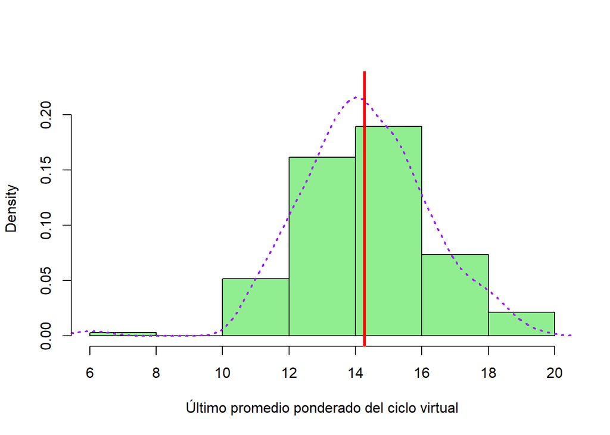

```r
hist(DfLast$PromUltimoCP, breaks = 6, freq = FALSE, col = "lightgreen", ylim = c(0,0.23), xlab = "Último promedio ponderado del ciclo virtual", main = "")
abline(v = mean(DfLast$PromUltimoCP), col ="red", lwd = 3)
lines(density(na.omit(DfLast$PromUltimoCP)), lty="dotted", lwd=2, col="purple")
```

- Observación

Los datos mayormente se concentran entre el intervalo de 12 a 16. Asimismo, la media es 14.27

**2. Promedio ponderado del último ciclo VIRTUAL (aproximado)**

Se estudiará la variable promedio del último ciclo virtual (PromUltimoCV), debido a que esta variable da indicios de cómo han sido las notas en la modalidad virtual, para luego compararlas con las notas del ciclo presencial. Luego de este proceso, se podrá comprobar si la virtualidad afectó el rendimiento de los alumnos de UTEC. Por ello, obtener los intervalos de confianza es relevante para nuestro estudio.

**2.1. Aplicación intervalos de confianza:**

En nuestro caso, con los datos buscamos un intervalo de confianza para la media muestral con un nivel de confianza del 95 %.

Estimación puntual de la media muestral

```r
mean(DfLast$PromUltimoCV)
```

```
## [1] 14.76354
```

Se creo una variable para estimación puntual de la desviación estándar muestral

```r
DEPromUltCV <- sd(DfLast$PromUltimoCV)
```

Intervalos de confianza

```r
nDfLast<-164
xbarras2<-mean(DfLast$PromUltimoCV)
conf=0.95
alpha.2<-(1-conf)/2
pcv<-(table(DfLast$PromUltimoCV)/length(DfLast$PromUltimoCV))[1]
zPromUltCV<- qt(alpha.2,df=nDfLast-1,lower.tail = F)
izqPromUltCV <- xbarras2 - zPromUltCV*DEPromUltCV/sqrt(nDfLast)
derPromUltCV <- xbarras2 + zPromUltCV*DEPromUltCV/sqrt(nDfLast)
cat("(",izqPromUltCV,",",derPromUltCV,")\n")
```

```
## ( 14.50097 , 15.0261 )
```

Calculamos la precisión del intervalo de confianza

```r
prescv<-zPromUltCV*sqrt((pcv*(1-pcv))/length(DfLast$PromUltimoCV))
```

Como se puede observar, el intervalo de confianza sería: (14.501, 15.0261) con una precisión de 0.012.

- Se creará un histograma del último promedio ponderado del ciclo virtual.

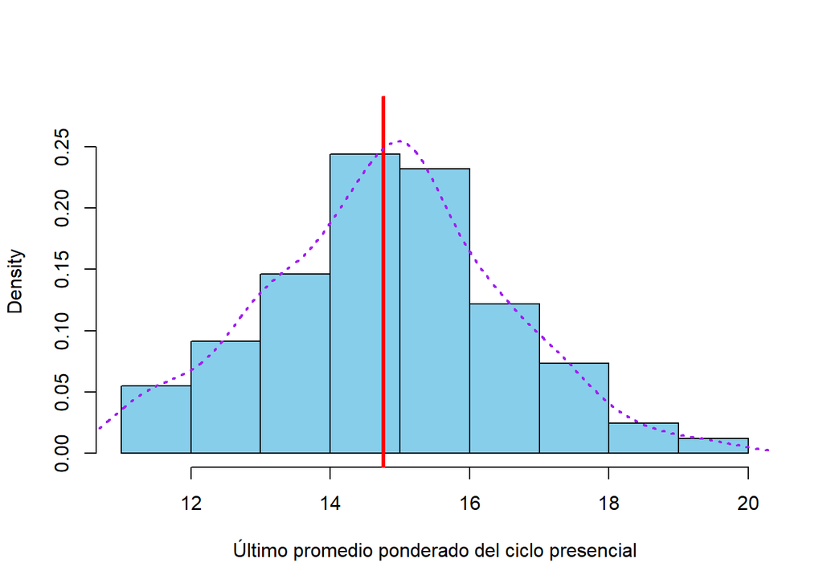

```r
hist(DfLast$PromUltimoCV, breaks = 7, freq = FALSE, col = "skyblue", ylim = c(0,0.28),xlab = "Último promedio ponderado del ciclo presencial", main = "")
abline(v = mean(DfLast$PromUltimoCV), col ="red", lwd = 3)
lines(density(na.omit(DfLast$PromUltimoCV)), lty="dotted", lwd=2, col="purple")
```

- Observación

Los datos mayormente se concentran entre el intervalo de 14 a 16. Asimismo, la media es 14.76

**3. Promedio ponderado del último ciclo VIRTUAL de alumnos que han desaprobado el ciclo presencial y virtual (aproximado)**

Hemos creado un nuevo dataframe, que contiene a los alumnos que desaprobaron cursos en ambas modalidades.

```r
DFJJ <- DfLast[(DfLast$CursoDesaprobadoCV == "Si") & (DfLast$CursoDesaprobadoCP == "Si"),]
```

**3.1 Aplicación intervalos de confianza:**

Estimación puntual de la media muestral

```r
mean(DFJJ$PromUltimoCV)
```

```
## [1] 13.87606
```

Estimación puntual de la desviación estándar muestral

```r
sd(DFJJ$PromUltimoCV)
```

```
## [1] 1.488798
```

Intervalos de confianza

```r
nDFJJ <- 66
xbarras3 <- mean(DFJJ$PromUltimoCV)
DEJJPromUltCV <- sd(DFJJ$PromUltimoCV)
conf = 0.95
alpha.2 <- (1-conf)/2
pjjcv<-(table(DFJJ$PromUltimoCV)/length(DFJJ$PromUltimoCV))[1]
zJJPromUltCV  <- qt(alpha.2,df=nDFJJ-1,lower.tail = F)
izqJJPromUltCV <- xbarras3 - zJJPromUltCV*DEJJPromUltCV/sqrt(nDFJJ)
derJJPromUltCV <- xbarras3 + zJJPromUltCV *DEJJPromUltCV/sqrt(nDFJJ)
cat("(",izqJJPromUltCV,",",derJJPromUltCV,")\n")
```

```
## ( 13.51007 , 14.24205 )
```

Calculamos la precisión del intervalo de confianza

```r
presjjcv<-zJJPromUltCV*sqrt((pjjcv*(1-pjjcv))/length(DFJJ$PromUltimoCV))
```

Como se puede observar, el intervalo de confianza sería: (13.5101, 14.2421) con una precisión de 0.03.

**4. Promedio ponderado aproximado del último ciclo PRESENCIAL de alumnos que han desaprobado ambas modalidades (presencial y virtual)**

Se estudiará la variable promedio del último ciclo presencial con respecto a un dataframe que contenga solo a los alumnos que han desaprobado ambas modalidades. Esto resulta relevante para el estudio, debido a que esta variable nos ayudará a determinar el rendimiento académico de los alumnos que han desaprobado ambas modalidades.

**4.1. Aplicación intervalos de confianza:**

Estimación puntual de la media muestral

```r
mean(DFJJ$PromUltimoCP)
```

```
## [1] 13.40697
```

Estimación puntual de la desviación estándar muestral

```r
sd(DFJJ$PromUltimoCP)
```

```
## [1] 1.522724
```

Intervalos de confianza

```r
nDFJJ <- 66
xbarras4 <- mean(DFJJ$PromUltimoCP)
DEJJPromUltCP <- sd(DFJJ$PromUltimoCP)
conf = 0.95
alpha.2 <- (1-conf)/2
pjjcp<-(table(DFJJ$PromUltimoCP)/length(DFJJ$PromUltimoCP))[1]
zJJPromUltCP <- qt(alpha.2,df=nDFJJ-1,lower.tail = F)

izqJJPromUltCP <- xbarras4 - zJJPromUltCP*DEJJPromUltCP/sqrt(nDFJJ)
derJJPromUltCP <- xbarras4 + zJJPromUltCP*DEJJPromUltCP/sqrt(nDFJJ)
cat("(",izqJJPromUltCP,",",derJJPromUltCP,")\n")
```

```
## ( 13.03264 , 13.7813 )
```

Calculamos la precisión del intervalo de confianza

```r
presjjcp<-zJJPromUltCP*sqrt((pjjcp*(1-pjjcp))/length(DFJJ$PromUltimoCP))
```

Como se puede observar, el intervalo de confianza sería: (13.0326, 13.7813) con una precisión de 0.03.

**5. Promedio ponderado del último ciclo VIRTUAL de alumnos que han aprobado en presencial y virtual (aproximado)**

Se estudiará la variable promedio del ultimo ciclo virtual con respecto a un data frame que contenga solo a los alumnos que han aprobado ambas modalidades. Esto resulta relevante para el estudio, debido a que esta variable nos ayudará a determinar el rendimiento académico de los alumnos que han aprobado ambas modalidades.

Hemos creado un nuevo data frame, que contiene a los que han aprobado cursos en ambas modalidades.

```r
DFAA <- DfLast[(DfLast$CursoDesaprobadoCV == "No") & (DfLast$CursoDesaprobadoCP == "No"),]
```

**5.1. Aplicación intervalos de confianza:**

Estimación de la media muestral

```r
mean(DFAA$PromUltimoCV)
```

```
## [1] 15.84775
```

Estimación de la desviación estándar

```r
sd(DFAA$PromUltimoCV)
```

```
## [1] 1.538188
```

Intervalos de confianza

```r
nDFAA  <- 40
xbarras5 <- mean(DFAA$PromUltimoCV)
DEAAPromUltCV <- sd(DFAA$PromUltimoCV)
conf = 0.95
alpha.2 <- (1-conf)/2
paacv<-(table(DFAA$PromUltimoCV)/length(DFAA$PromUltimoCV))[1]
zAAPromUltCV <- qt(alpha.2,df=nDFAA-1,lower.tail = F)

izqAAPromUltCV <- xbarras5 - zAAPromUltCV*DEAAPromUltCV/sqrt(nDFAA)
derAAPromUltCV <- xbarras5 + zAAPromUltCV*DEAAPromUltCV/sqrt(nDFAA)
cat("(",izqAAPromUltCV,",",derAAPromUltCV,")\n")
```

```
## ( 15.35581 , 16.33969 )
```

Calculamos la precisión del intervalo de confianza

```r
presaacv<-zAAPromUltCV*sqrt((paacv*(1-paacv))/length(DFAA$PromUltimoCV))
```

Como se puede observar, el intervalo de confianza sería: (15.3558, 16.3397) con una precisión de 0.05.

**6. Promedio ponderado del último ciclo PRESENCIAL de alumnos que han aprobado en presencial y virtual (aproximado)**

Se estudiará la variable promedio del ultimo ciclo presencial con respecto a un data frame que contenga solo a los alumnos que han aprobado ambas modalidades. Esto resulta relevante para el estudio, debido a que esta variable nos ayudará a determinar el rendimiento académico de las personas que han aprobado ambas modalidades

**6.1. Aplicación intervalos de confianza:**

Estimación de la media muestral

```r
mean(DFAA$PromUltimoCP)
```

```
## [1] 15.67825
```

Estimación de la desviación estándar

```r
sd(DFAA$PromUltimoCP)
```

```
## [1] 1.90555
```

Intervalos de confianza

```r
nDFAA  <- 40
xbarras6 <- mean(DFAA$PromUltimoCP)
DEAAPromUltCP <- sd(DFAA$PromUltimoCP)
conf = 0.95
alpha.2 <- (1-conf)/2
paacp<-(table(DFAA$PromUltimoCP)/length(DFAA$PromUltimoCP))[1]
zAAPromUltCP <- qt(alpha.2,df=nDFAA -1,lower.tail = F)

izqAAPromUltCP <- xbarras6 - zAAPromUltCP*DEAAPromUltCP/sqrt(nDFAA)
derAAPromUltCP <- xbarras6 + zAAPromUltCP*DEAAPromUltCP/sqrt(nDFAA)
cat("(",izqAAPromUltCP,",",derAAPromUltCP,")\n")
```

```
## ( 15.06883 , 16.28767 )
```

Calculamos la precisión del intervalo de confianza

```r
presaacp<-zAAPromUltCP*sqrt((paacp*(1-paacp))/length(DFAA$PromUltimoCP))
```

Como se puede observar, el intervalo de confianza sería: (15.0688, 16.2877) con una precisión de 0.084.

**7. Promedio de la cantidad de cursos llevados en el ciclo presencial**

**7.1. Aplicación de los intervalos de confianza**

Estimación puntual de la media muestral

```r
mean(DfLast$NumCursosMaxCP)
```

```
## [1] 6.573598
```

Estimación puntual de la desviación estándar muestral

```r
DECantCP <- sd(DfLast$NumCursosMaxCP)
```

Intervalos de confianza:

```r
nDfLast<-164
BarrasCantCP<-mean(DfLast$NumCursosMaxCP)
conf = 0.95
alpha.2<-(1-conf)/2
pcmp<-(table(DfLast$NumCursosMaxCP)/length(DfLast$NumCursosMaxCP))[1]
ZCantCP<- qt(alpha.2,df=nDfLast-1,lower.tail = F)
izqCantCP <- BarrasCantCP - ZCantCP*DECantCP/sqrt(nDfLast)
derCantCP <- BarrasCantCP + ZCantCP*DECantCP/sqrt(nDfLast)
cat("(",izqCantCP ,",",derCantCP,")\n")
```

```
## ( 6.352839 , 6.794356 )
```

```r
prescmp<-ZCantCP*sqrt((pcmp*(1-pcmp))/length(DfLast$NumCursosMaxCP))
```

Como se puede observar, el intervalo de confianza sería: (6.3528, 6.7944) con una precisión de 0.012.

**8. Promedio de la cantidad de curso llevados en el ciclo virtual**

**8.1 Aplicación de los intervalos de confianza**

Estimación puntual de la media muestral

```r
mean(DfLast$NumCursosMaxCV)
```

```
## [1] 6.523902
```

Estimación puntual de la desviación estándar muestral

```r
DECantCV <- sd(DfLast$NumCursosMaxCV)
```

Intervalos de confianza

```r
nDfLast<-164
DECantCV <- sd(DfLast$NumCursosMaxCV)
BarrasCantCV<-mean(DfLast$NumCursosMaxCV)
conf = 0.95
alpha.2<-(1-conf)/2
pcmv<-(table(DfLast$NumCursosMaxCV)/length(DfLast$NumCursosMaxCV))[1]
ZCantCV<- qt(alpha.2,df=nDfLast-1,lower.tail = F)

izqCantCV <- BarrasCantCV - ZCantCV*DECantCV/sqrt(nDfLast)
derCantCV <- BarrasCantCV + ZCantCV*DECantCV/sqrt(nDfLast)
cat("(",izqCantCV ,",",derCantCV,")\n")
```

```
## ( 6.294766 , 6.753039 )
```

Calculamos la precisión del intervalo de confianza

```r
prescmv<-ZCantCV*sqrt((pcmv*(1-pcmv))/length(DfLast$NumCursosMaxCV))
```

Como se puede observar, el intervalo de confianza sería: (6.2948, 6.753) con una precisión de 0.012.

```r
fi <- mean(DfLast$PromUltimoCP)
fi
```

```
## [1] 14.2747
```

**XII. Prueba de hipótesis**

Para la evaluación de hipótesis se considerará una significancia α=0.05

```r
 al <- 0.05
```

**Prueba de hipótesis 1**

> $H_{o}$: Promedio Virtual igual o mayor a 14.27 (media del último promedio ponderado de ciclo presencial).

$Promedio \; Virtual >= 14.27$

> $H_{a}$:Promedio Virtual menor a 14.27 (media del último promedio ponderado de ciclo presencial).

$Promedio \; Virtual < 14.27$

Para esta hipótesis utilizamos el Z, ya que es una hipótesis unilateral con cola inferior

Hallamos nuestro Z observado y Z crítico

```r
pu0 <- mean(DfLast$PromUltimoCP)
pa0 <- mean(DfLast$PromUltimoCV)
zObservadoCV <- round(((pu0-pa0)/((sd(DfLast$PromUltimoCV)))/sqrt(nDfLast)),3)

zCriticoCV <- round(qnorm(0.05,lower.tail = TRUE),3)
zCriticoCV
```

```
## [1] -1.645
```

```r
zObservadoCV
```

```
## [1] -0.022
```

Señalamos la zona de no rechazo, Z crítico y Z observado

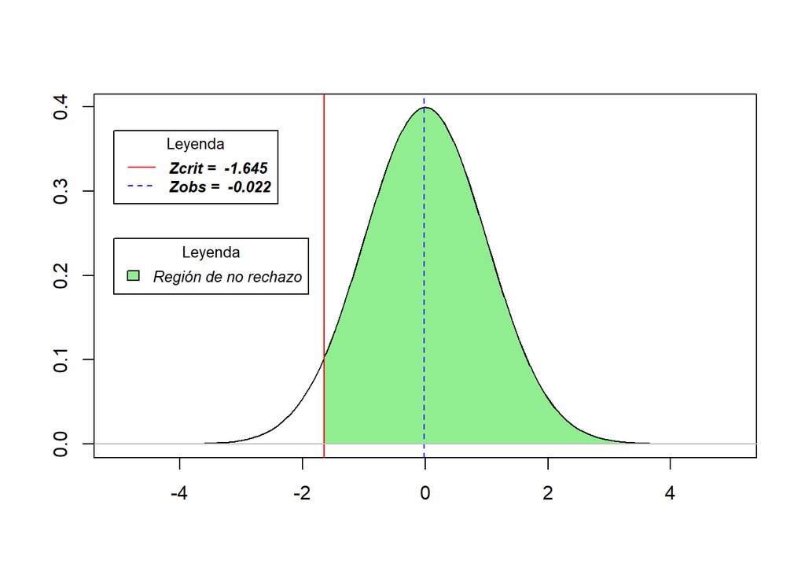

```r
Xs <- seq(-5,5, by = 0.1)
C1<-seq(zCriticoCV, 4, by=0.01)
plot(Xs, dnorm(Xs), type = "l", xlab= "", ylab= "")
xP1 <- c(zCriticoCV,C1,4)
yP1 <- c(0,dnorm(C1,0,1),0)
polygon(xP1,yP1,col="light green")

abline(v=c(zCriticoCV,zObservadoCV), lty = c(1,2), col = c("red", "blue"))
abline(h = 0, col = "gray")

legend(x="bottomleft", inset = c(0.030, 0.450)
       ,legend = c("Región de no rechazo"), col=c("lightblue"), title ="Leyenda", text.font = 3,fill=c(col="light green"),cex=0.8)
legend(x="topleft", inset = c(0.030, 0.10)
       ,legend = c(paste("Zcrit = ", ( zCriticoCV)), paste("Zobs = ", (zObservadoCV)))
       ,col=c("red","blue"),lty = 1:2,title ="Leyenda",text.font = 4,cex = 0.8)
```

Hallamos el p value

```r
pvalorCV<-pnorm(zObservadoCV)
pvalorCV
```

```
## [1] 0.491224
```

Nuestro el pvalue=0.4910 es mayor que la significancia α=0.05, no se rechaza la hipótesis nula tras no haber encontrado evidencia suficiente.

**Prueba de hipótesis 2**

> $H_{o}$: El PROMEDIO PONDERADO DEL ÚLTIMO CICLO VIRTUAL de los estudiantes que no desaprobaron ningún curso en virtual ni en presencial es mayor o igual al último promedio ponderado del último ciclo virtual de los estudiantes que si desaprobaron cursos en ambas modalidades.

> $H_{a}$: El PROMEDIO PONDERADO DEL ÚLTIMO CICLO VIRTUAL de los estudiantes que no desaprobaron ningún curso en virtual ni en presencial es menor al último promedio ponderado del último ciclo virtual de los estudiantes que si desaprobaron cursos en ambas modalidades.

Para esta hipótesis utilizamos el Z, ya que es una hipótesis unilateral con cola superior

Hallando el Z observado y el Z crítico

```r
pu <- mean(DFAA$PromUltimoCV)
pa <- mean(DFJJ$PromUltimoCV)
zObservadoAACV <- round(((pu-pa)/((sd(DFJJ$PromUltimoCV)))/sqrt(66)),3)

zCriticoAACV <- round(qnorm(0.05,lower.tail = 0),3)
zCriticoAACV
```

```
## [1] 1.645
```

```r
zObservadoAACV
```

```
## [1] 0.163
```

Nuestro Z observado tiene un valor 0.163 y nuestro Z crítico es 1.645

Señalamos la zona de no rechazo, Z crítico y Z observado

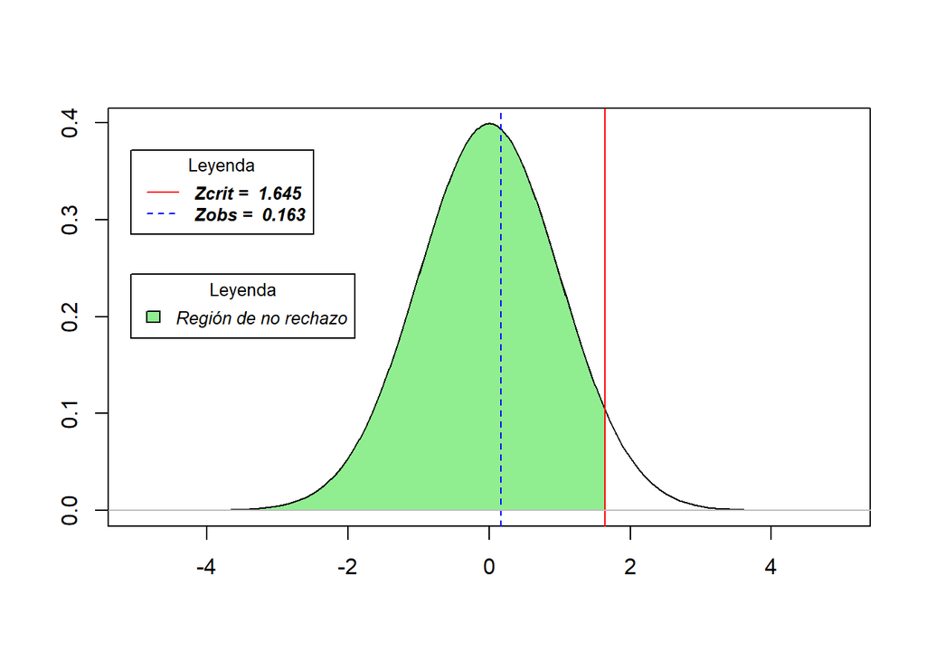

```r
xAACV<-seq(-5,5,by=0.1)
C2<-seq(-4, zCriticoAACV, by=0.01)

plot(xAACV,dnorm(xAACV),type="l", xlab= "", ylab= "")
xP2 <- c(-4,C2,zCriticoAACV)
yP2 <- c(0,dnorm(C2,0,1),0)
polygon(xP2,yP2,col="light green")

abline(v=c(zCriticoAACV, zObservadoAACV),lty=c(1,2),col=c("red","blue"))
abline(h=0,col="gray")
legend(x="bottomleft", inset = c(0.030, 0.450)
       ,legend = c("Región de no rechazo"), col=c("lightblue"), title ="Leyenda", text.font = 3,fill=c(col="light green"),cex=0.8)
legend(x="topleft", inset = c(0.030, 0.10)
       ,legend = c(paste("Zcrit = ", ( zCriticoAACV)), paste("Zobs = ", (zObservadoAACV)))
       ,col=c("red","blue"),lty = 1:2,title ="Leyenda",text.font = 4,cex = 0.8)
```

- Hallamos p value

```r
pvalorAACV<-pnorm(zObservadoAACV)
pvalorAACV
```

```
## [1] 0.5647408
```

Nuestro pvalue=0.5647 es mayor que la significancia α=0.05, no se rechaza la hipótesis nula tras no haber encontrado evidencia suficiente.

Podemos afirmar que, el último promedio virtual de los estudiantes que no desaprobaron ni en virtual ni en presencial es mayor o igual a el promedio de los estudiantes que si desaprobaron ambas modalidades.

**Prueba de hipótesis 3**

> $H_{o}$: El PROMEDIO PONDERADO DEL ÚLTIMO CICLO PRESENCIAL de los estudiantes que no desaprobaron ningún curso en presencial ni en virtual es mayor o igual a el promedio de los estudiantes que si desaprobaron ambas modalidades  
> al último promedio ponderado del último ciclo virtual de los estudiantes que si desaprobaron cursos en ambas modalidades

> $H_{a}$: El PROMEDIO PONDERADO DEL ÚLTIMO CICLO PRESENCIAL de los estudiantes que no desaprobaron ningún curso en presencial ni en virtual es menor a el promedio de los estudiantes que si desaprobaron ambas modalidades

Hallando el Z observado y el Z crítico

```r
pu2 <- mean(DFAA$PromUltimoCP)
pa2 <- mean(DFJJ$PromUltimoCP)
zObservadoAACP <- round(((pu2-pa2)/((sd(DFJJ$PromUltimoCP)))/sqrt(66)),3)

zCriticoAACP <- round(qnorm(0.05,lower.tail = TRUE),3)
zCriticoAACP
```

```
## [1] -1.645
```

```r
zObservadoAACP
```

```
## [1] 0.184
```

Nuestro Z observado tiene un valor 0.184 y nuestro Z crítico es -1.645

Señalamos la zona de no rechazo, Z crítico y Z observado

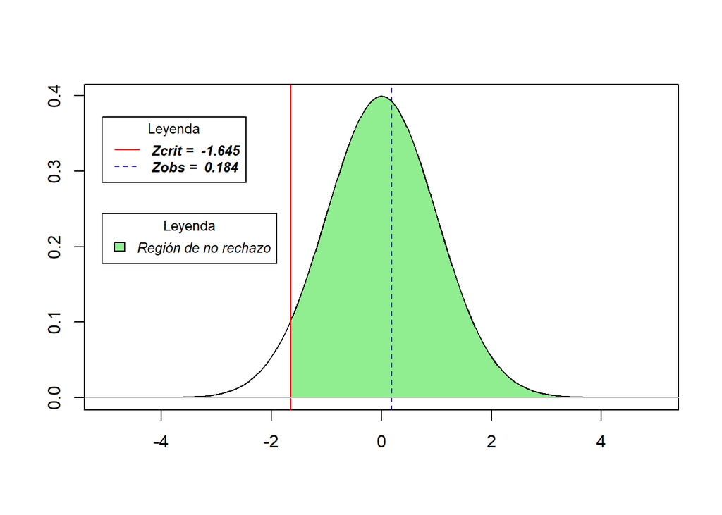

```r
xAACP<-seq(-5,5,by=0.1)
C3<-seq(zCriticoAACP,4,by=0.01)
plot(xAACP,dnorm(xAACP),type="l", xlab= "", ylab= "")
xP3 <- c(zCriticoAACP,C3,4)
yP3 <- c(0,dnorm(C3,0,1),0)
polygon(xP3,yP3,col="light green")

abline(v=c(zCriticoAACP ,zObservadoAACP),lty=c(1,2),col=c("red","blue"))
abline(h=0,col="gray")

legend(x="bottomleft", inset = c(0.030, 0.450)
       ,legend = c("Región de no rechazo"), col=c("lightblue"), title ="Leyenda", text.font = 3,fill=c(col="light green"),cex=0.8)
legend(x="topleft", inset = c(0.030, 0.10)
       ,legend = c(paste("Zcrit = ",(zCriticoAACP)), paste("Zobs = ",(zObservadoAACP)))
       ,col=c("red","blue"),lty = 1:2,title ="Leyenda",text.font = 4,cex = 0.8)
```

- Hallamos p value

```r
pvalorAACP<-pnorm(zObservadoAACP)
pvalorAACP
```

```
## [1] 0.5729933
```

Nuestro pvalue = 0.5728 es mayor que la significancia α=0.05, no se rechaza la hipótesis nula tras no haber encontrado evidencia suficiente.

Podemos afirmar que, el último promedio presencial de los estudiantes que no desaprobaron ni en presencial ni en virtual es mayor o igual a el promedio de los estudiantes que si desaprobaron ambas modalidades.

**XIII. Regresión**

Para entender el comportamiento de nuestras variables Promedio ponderado del último ciclo virtual con respecto al Promedio ponderado del último ciclo presencial, se empleará gráficos de dispersión.

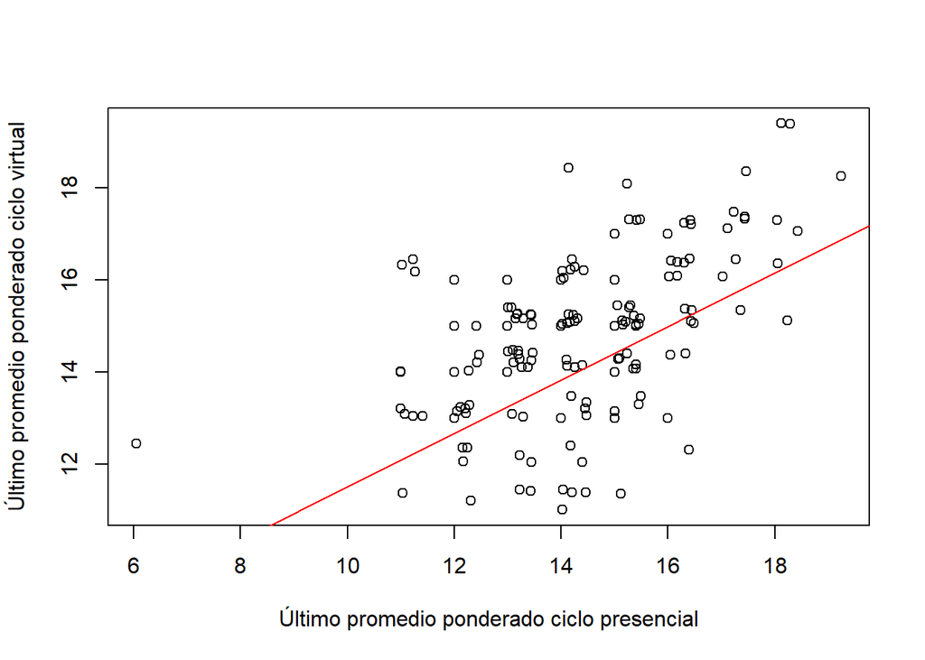

```r
plot(DfLast$PromUltimoCP, DfLast$PromUltimoCV, xlab = "Último promedio ponderado ciclo presencial", ylab = "Último promedio ponderado ciclo virtual")

lm1<-lm(DfLast$PromUltimoCP ~ DfLast$PromUltimoCV)
abline(lm1, col = "red")
```

Resumen de la regresión:

```r
regresion <- lm(formula = DfLast$PromUltimoCP ~ DfLast$PromUltimoCV)
summary(regresion)
```

```
##
## Call:
## lm(formula = DfLast$PromUltimoCP ~ DfLast$PromUltimoCV)
##
## Residuals:
##    Min     1Q Median     3Q    Max
## -6.883 -1.084 -0.205  1.140  3.759
##
## Coefficients:
##                     Estimate Std. Error t value Pr(>|t|)
## (Intercept)          5.71623    1.10970   5.151 7.44e-07 ***
## DfLast$PromUltimoCV  0.57970    0.07467   7.763 8.85e-13 ***
## ---
## Signif. codes:  0 '***' 0.001 '**' 0.01 '*' 0.05 '.' 0.1 ' ' 1
##
## Residual standard error: 1.623 on 162 degrees of freedom
## Multiple R-squared:  0.2711, Adjusted R-squared:  0.2666
## F-statistic: 60.27 on 1 and 162 DF,  p-value: 8.848e-13
```

Realizamos esta regresión para poder observar si es que los promedios académicos en ambas modalidades guardan una relación. Sin embargo, podemos observar la existencia de datos atípicos.

En el intercepto podemos observar que el p value es menor a la significancia (0.05). Por tal motivo, lo podemos rechazar y afirmar que esta es una variable significativa.

Examinando la pendiente, el p value es menor a la significancia. Por lo tanto, es una variable significativa. Además, al ser menor el p value, se rechaza.

En general la regresión, tiene un p value menor a 0.05. Lo cual, nos indica que la regresión es significativa.

El coeficiente de determinación es bajo, ya que solo explica el 26.66% de la variabilidad de la variable independiente.

Nuestro $R^2$ es: 0.2666

**XIV. Conclusiones**

Respondiendo nuestro objetivo principal, comparando el rendimiento académico con los promedios ponderados de los últimos ciclo presencial y virtual, los estudiantes aumentaron levemente su promedio ponderado.

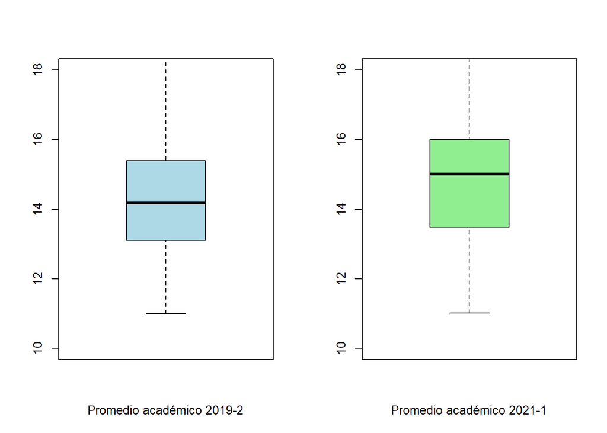

```r
mat <- matrix(c(1, 2),
              nrow = 2, ncol = 2,
              byrow = TRUE)

layout(mat = mat)

set.seed(6)
boxplot( DfLast$PromUltimoCP, xlab = "Promedio académico 2019-2", ylim=c(10,18), col = c("lightblue"))
boxplot(DfLast$PromUltimoCV, xlab = "Promedio académico 2021-1", ylim=c(10,18), col = c("lightgreen"))
```

Asimismo, los estudiantes que aprobaron todos los cursos en ambas modalidades siguen manteniendo un promedio ponderado mayor a los estudiantes que desaprobaron cursos en ambas modalidades, confirmando que la virtualidad no les afectó en gran magnitud.

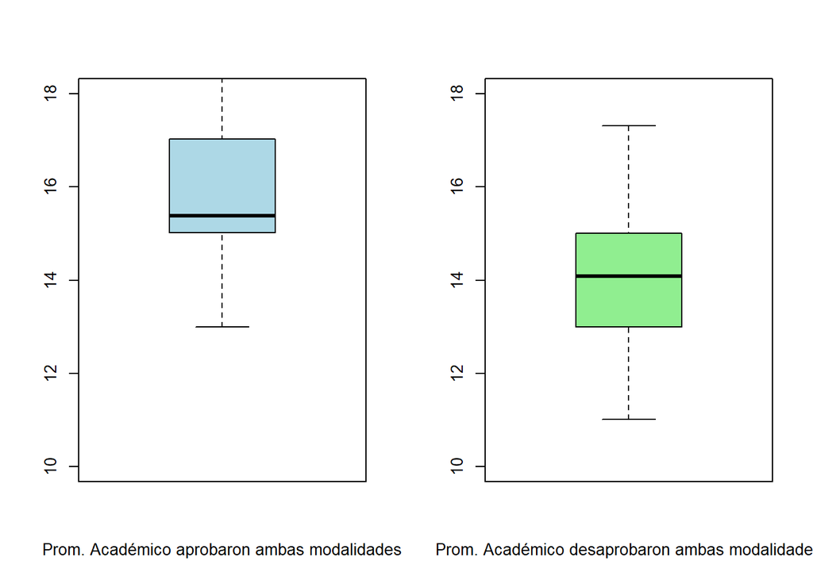

```r
mat <- matrix(c(1, 2),
              nrow = 2, ncol = 2,
              byrow = TRUE)

layout(mat = mat)

set.seed(6)
boxplot( DFAA$PromUltimoCV, xlab = "Prom. Académico aprobaron ambas modalidades", ylim=c(10,18), col = c("lightblue"))
boxplot(DFJJ$PromUltimoCV, xlab = "Prom. Académico desaprobaron ambas modalidades", ylim=c(10,18), col = c("lightgreen"))
```

**GRACIAS**